# Prewhitening Analysis of the Memory Words Task from the MSC Dataset

John Koo

For this analysis, we will focus on session 1 for subject 1. We will look at the T1-weighted scans. This particular session consisted of 121 scans of $38 \times 49 \times 38$ voxels. Each voxel is $4 \times 4 \times 4$ mm. The scans were taken at $2.2$ second intervals.

First, we’ll just fit the GLM model on the data as is and see what we get:

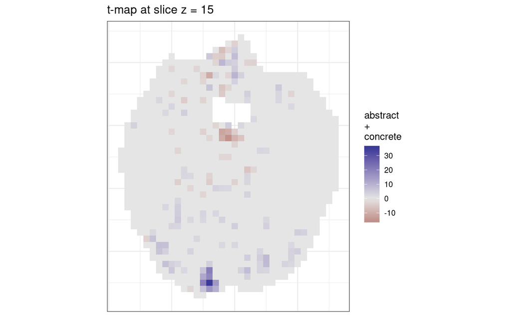

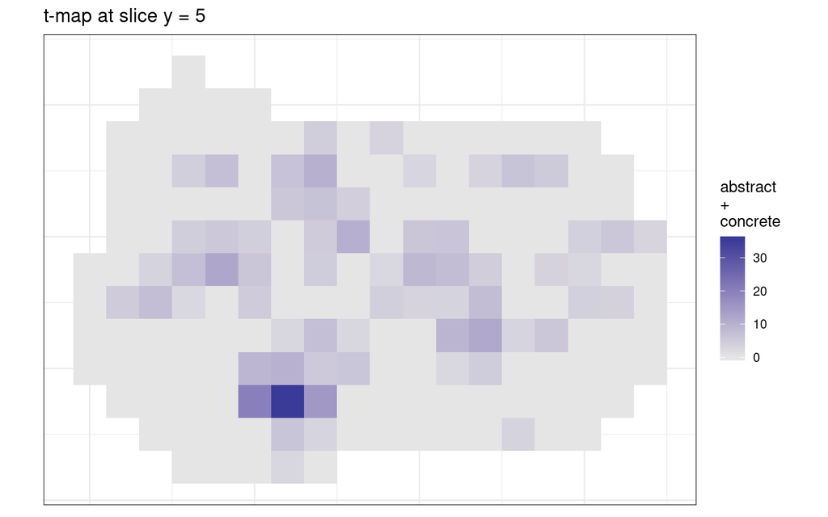

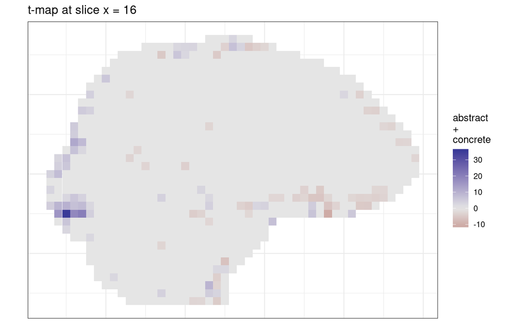

The inputs are the six motion parameters, two drift parameters, and two parameters of interest referring to the two subtasks (“abstract” and “concrete”). The contrast vector is $\begin{bmatrix} 1 & 1 \end{bmatrix}^\top$. Previous data analysis suggests that the two subtasks activate similar parts of the brain, the visual cortex.

Since the observations are sequential in time, we expect the observations (and therefore residuals) to be autocorrelated, violating the constant variance assumption of OLS. We can check for autocorrelation by fitting ACF models on the residuals at each voxel. Since we have many voxels’ worth of BOLD timeseries, one thing we can try looking at is the mean ACF coefficients:

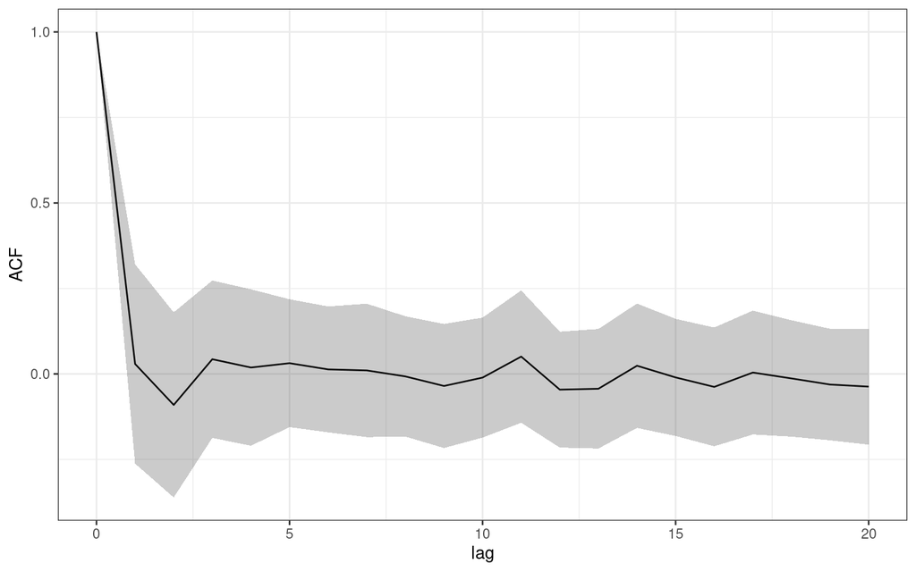

In the above plot, the solid line is the mean ACF and the ribbon represents $\pm 2$ standard deviations.

On average, it seems like there is very little autocorrelation. However, this doesn’t mean that is the case across every voxel. We can try looking at how the lag changes across voxels.

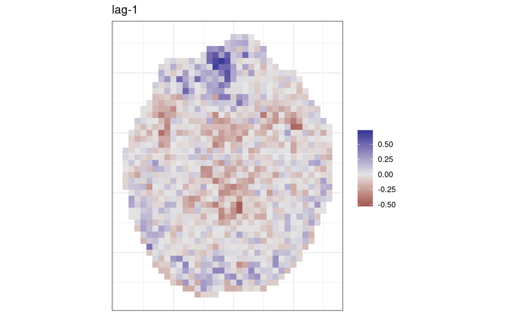

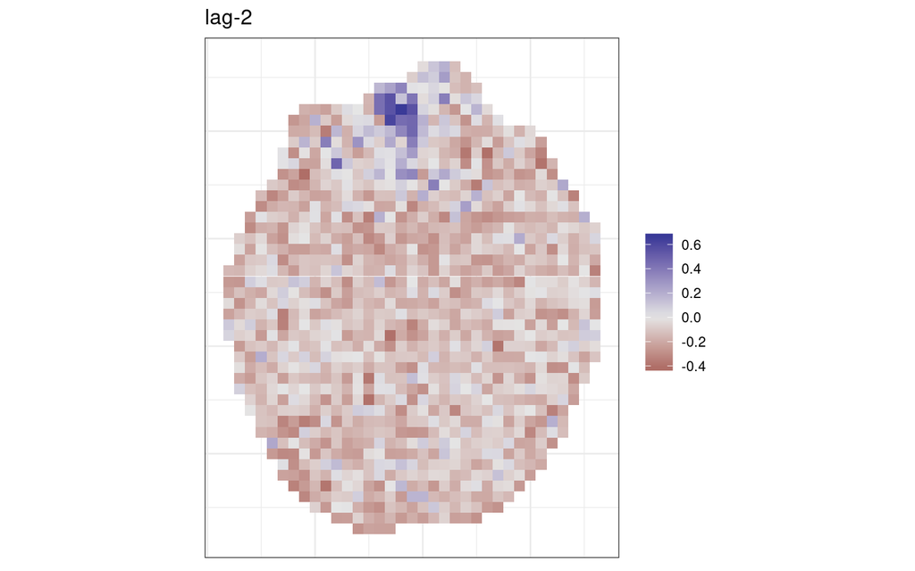

It seems like the highest autocorrelation for both lag-1 and lag-2 occurs in the prefrontal cortex. If the AR(1) model is best for these data, then we would expect the lag-2 coefficients to be equal to the square of the lag-1 coefficients. Since most of the lag-2 coefficients are negative, this clearly is not the case, but we can check anyway:

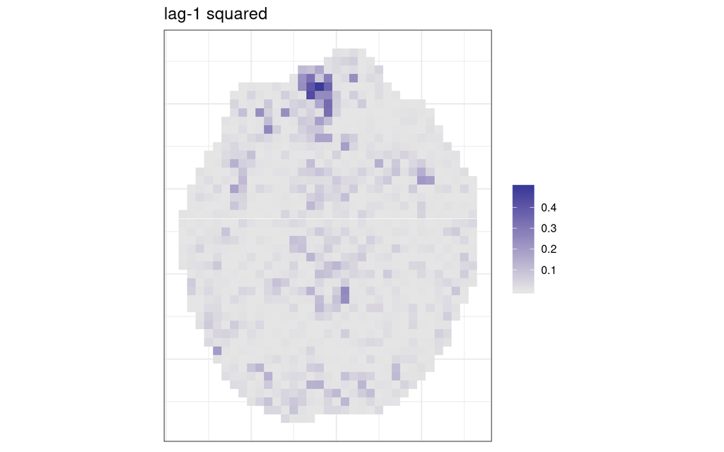

One thing we could do here is estimate an autocorrelation matrix $V$ for each voxel and use that to whiten each voxel. But to restrict our model, we’ll just fit a global autocorrelation matrix. To compensate, we can try adding a few extra terms. For now, we’ll use an AR(4) model, although the data don’t suggest the mean lag is much more than 1 or 2.

We have multiple timeseries, one for each voxel, so we’ll just do the naive thing and fit AR(4) models for each voxel and average out the estimated parameters.

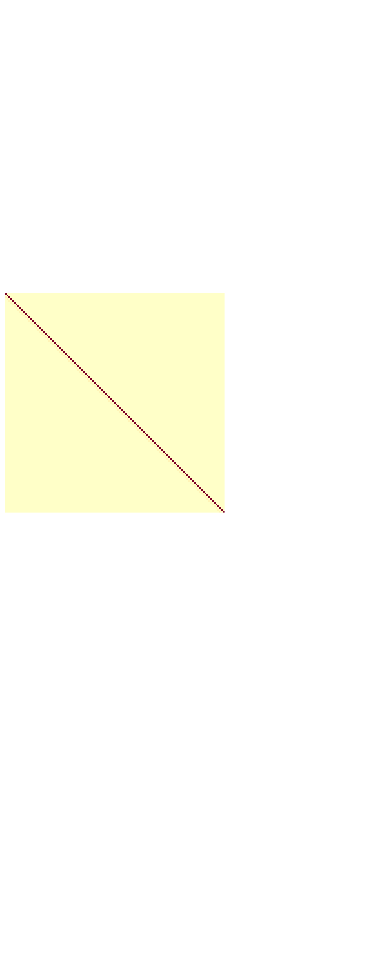

As expected from the average autocorrelation plot, the autocorrelation matrix is close to the identity. We can also check if this looks anything like the mean ACF plot from before:

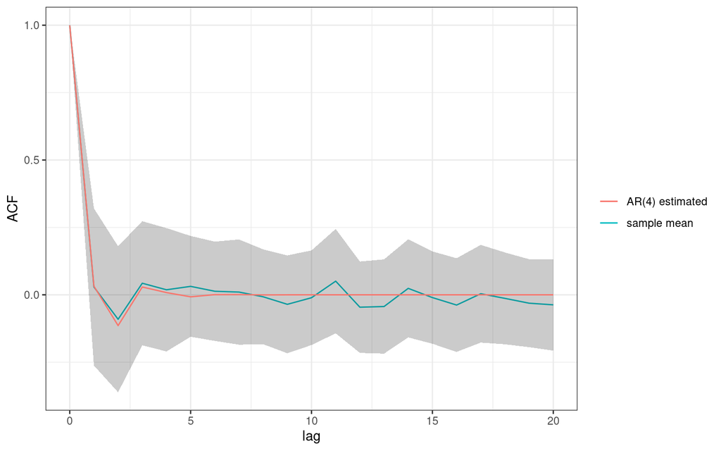

In either case, everything is very close to 0.

We can finally apply the prewhitening and fit a GLM on the prewhitened data:

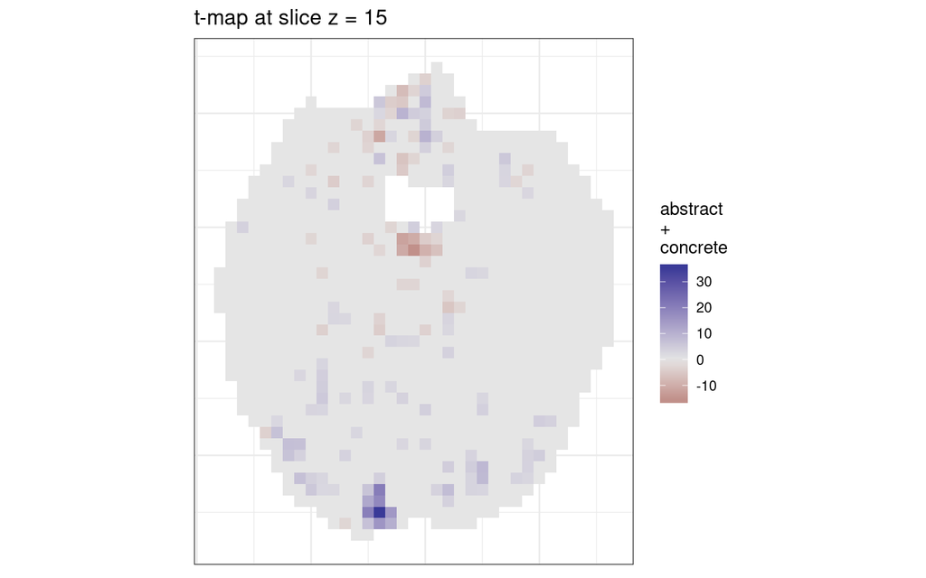

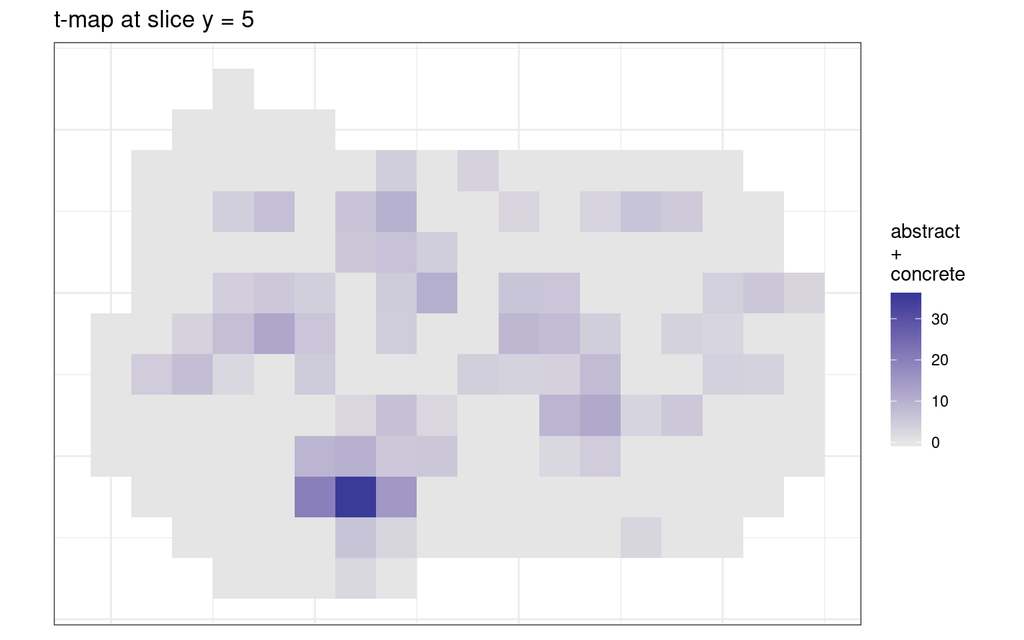

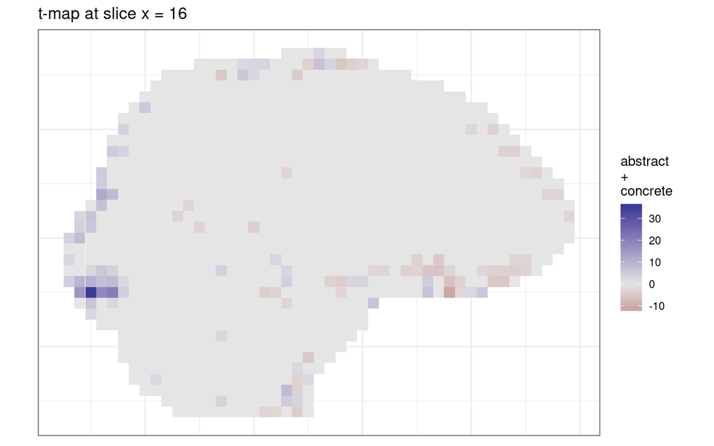